# Group 11 _Phase 3 Submission

### SK_ID_PREV and SK_ID_CURR

```python
print("* All records have distinct SK_ID_CURR? \t", len(df_credit['SK_ID_CURR'].unique()) == df_credit.shape[0])
print("* Total number of unique SK_ID_CURR   : \t", len(df_credit['SK_ID_CURR'].unique()))
print("* All records have distinct SK_ID_PREV? \t", len(df_credit['SK_ID_PREV'].unique()) == df_credit.shape[0])
print("* Total number of unique SK_ID_PREV   : \t", len(df_credit['SK_ID_PREV'].unique()))
```

```
* All records have distinct SK_ID_CURR? 	 False
* Total number of unique SK_ID_CURR   : 	 103558
* All records have distinct SK_ID_PREV? 	 False
* Total number of unique SK_ID_PREV   : 	 104307
```

### SK_DPD and SK_DPD_DEF

```python
print("* Values of SK_DPD\n")
# display(df_credit['SK_DPD'].value_counts())
display(df_credit['SK_DPD'].groupby(pd.cut(df_credit['SK_DPD'],[0,100,200,500,1000,2000,5000])).count())

print("* Values of SK_DPD_DEF\n")
# display(df_credit['SK_DPD_DEF'].value_counts())
display(df_credit['SK_DPD_DEF'].groupby(pd.cut(df_credit['SK_DPD_DEF'],[0,100,200,500,1000,2000,5000])).count())
```

```
* Values of SK_DPD
```

```
SK_DPD
(0, 100]        106769
(100, 200]        4915
(200, 500]       12673
(500, 1000]      15095
(1000, 2000]     13447
(2000, 5000]       456
Name: SK_DPD, dtype: int64
```

```
* Values of SK_DPD_DEF
```

```
SK_DPD_DEF
(0, 100]        88307
(100, 200]        113
(200, 500]        172
(500, 1000]       240
(1000, 2000]      354
(2000, 5000]      154
Name: SK_DPD_DEF, dtype: int64
```

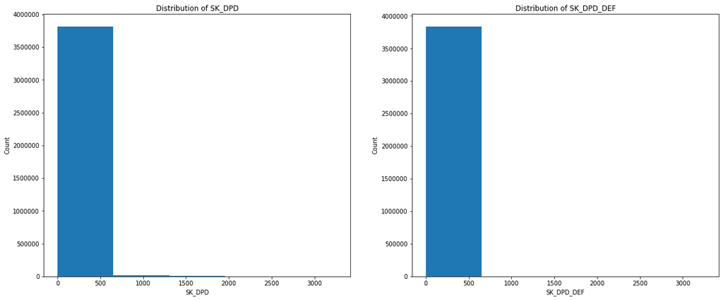

```python
plt.figure(figsize=(20,8))
plt.subplot(121)
_ = plt.hist(df_credit['SK_DPD'], bins=5)
plt.xlabel("SK_DPD")
plt.ylabel("Count")
plt.title("Distribution of SK_DPD")
plt.subplot(122)
_ = plt.hist(df_credit['SK_DPD_DEF'], bins=5)
plt.xlabel("SK_DPD_DEF")
plt.ylabel("Count")
plt.title("Distribution of SK_DPD_DEF")
```

```python
print(f"* SK_DPD and SK_DPD_DEF are different for {len(df_credit[df_credit.SK_DPD != df_credit.SK_DPD_DEF])} records")
# We will use the the SK_PDP for evaluating how many DPD (Days past due) during the month on the previous credit since the amount is larger
```

```
* SK_DPD and SK_DPD_DEF are different for 64439 records
```

### NAME_CONTRACT_STATUS

```python
df_credit['NAME_CONTRACT_STATUS'].value_counts()
```

```
Active           3698436
Completed         128918
Signed             11058
Demand              1365
Sent proposal        513
Refused               17
Approved               5
Name: NAME_CONTRACT_STATUS, dtype: int64
```

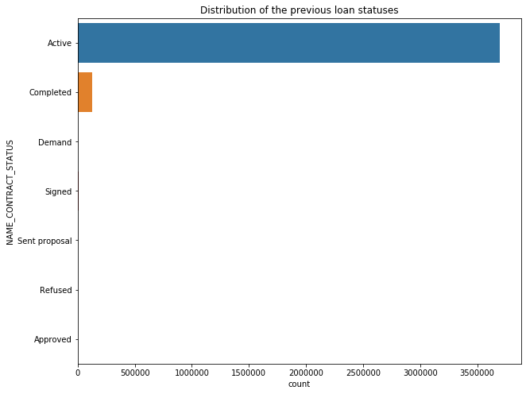

```python
plt.figure(figsize=(10,8))
sns.countplot(y='NAME_CONTRACT_STATUS', data=df_credit)
plt.title("Distribution of the previous loan statuses")
```

## Dataset: installments_payments

```
************************** installments_payments ******************************

Performing basic EDA on installments_payments dataset

* The dataset has 13605401 rows and 8 columns.

* First 10 rows of the dataset:
```

|  | SK_ID_PREV | SK_ID_CURR | NUM_INSTALMENT_VERSION | NUM_INSTALMENT_NUMBER | DAYS_INSTALMENT | DAYS_ENTRY_PAYMENT | AMT_INSTALMENT | AMT_PAYMENT |
| --- | --- | --- | --- | --- | --- | --- | --- | --- |
| 0 | 1054186 | 161674 | 1.0 | 6 | -1180.0 | -1187.0 | 6948.360 | 6948.360 |
| 1 | 1330831 | 151639 | 0.0 | 34 | -2156.0 | -2156.0 | 1716.525 | 1716.525 |
| 2 | 2085231 | 193053 | 2.0 | 1 | -63.0 | -63.0 | 25425.000 | 25425.000 |
| 3 | 2452527 | 199697 | 1.0 | 3 | -2418.0 | -2426.0 | 24350.130 | 24350.130 |
| 4 | 2714724 | 167756 | 1.0 | 2 | -1383.0 | -1366.0 | 2165.040 | 2160.585 |
| 5 | 1137312 | 164489 | 1.0 | 12 | -1384.0 | -1417.0 | 5970.375 | 5970.375 |
| 6 | 2234264 | 184693 | 4.0 | 11 | -349.0 | -352.0 | 29432.295 | 29432.295 |
| 7 | 1818599 | 111420 | 2.0 | 4 | -968.0 | -994.0 | 17862.165 | 17862.165 |
| 8 | 2723183 | 112102 | 0.0 | 14 | -197.0 | -197.0 | 70.740 | 70.740 |
| 9 | 1413990 | 109741 | 1.0 | 4 | -570.0 | -609.0 | 14308.470 | 14308.470 |

```
* Describing the dataset statistics:
```

|  | SK_ID_PREV | SK_ID_CURR | NUM_INSTALMENT_VERSION | NUM_INSTALMENT_NUMBER | DAYS_INSTALMENT | DAYS_ENTRY_PAYMENT | AMT_INSTALMENT | AMT_PAYMENT |
| --- | --- | --- | --- | --- | --- | --- | --- | --- |
| count | 1.360540e+07 | 1.360540e+07 | 1.360540e+07 | 1.360540e+07 | 1.360540e+07 | 1.360250e+07 | 1.360540e+07 | 1.360250e+07 |
| mean | 1.903365e+06 | 2.784449e+05 | 8.566373e-01 | 1.887090e+01 | -1.042270e+03 | -1.051114e+03 | 1.705091e+04 | 1.723822e+04 |
| std | 5.362029e+05 | 1.027183e+05 | 1.035216e+00 | 2.666407e+01 | 8.009463e+02 | 8.005859e+02 | 5.057025e+04 | 5.473578e+04 |
| min | 1.000001e+06 | 1.000010e+05 | 0.000000e+00 | 1.000000e+00 | -2.922000e+03 | -4.921000e+03 | 0.000000e+00 | 0.000000e+00 |
| 25% | 1.434191e+06 | 1.896390e+05 | 0.000000e+00 | 4.000000e+00 | -1.654000e+03 | -1.662000e+03 | 4.226085e+03 | 3.398265e+03 |
| 50% | 1.896520e+06 | 2.786850e+05 | 1.000000e+00 | 8.000000e+00 | -8.180000e+02 | -8.270000e+02 | 8.884080e+03 | 8.125515e+03 |
| 75% | 2.369094e+06 | 3.675300e+05 | 1.000000e+00 | 1.900000e+01 | -3.610000e+02 | -3.700000e+02 | 1.671021e+04 | 1.610842e+04 |
| max | 2.843499e+06 | 4.562550e+05 | 1.780000e+02 | 2.770000e+02 | -1.000000e+00 | -1.000000e+00 | 3.771488e+06 | 3.771488e+06 |

```
* Fetching info of the dataset:

<class 'pandas.core.frame.DataFrame'>
RangeIndex: 13605401 entries, 0 to 13605400
Data columns (total 8 columns):
 #   Column                  Dtype
---  ------                  -----
 0   SK_ID_PREV              int64
 1   SK_ID_CURR              int64
 2   NUM_INSTALMENT_VERSION  float64
 3   NUM_INSTALMENT_NUMBER   int64
 4   DAYS_INSTALMENT         float64
 5   DAYS_ENTRY_PAYMENT      float64
 6   AMT_INSTALMENT          float64
 7   AMT_PAYMENT             float64
dtypes: float64(5), int64(3)
memory usage: 830.4 MB
```

```
None
```

```
* Check data distribution:
```

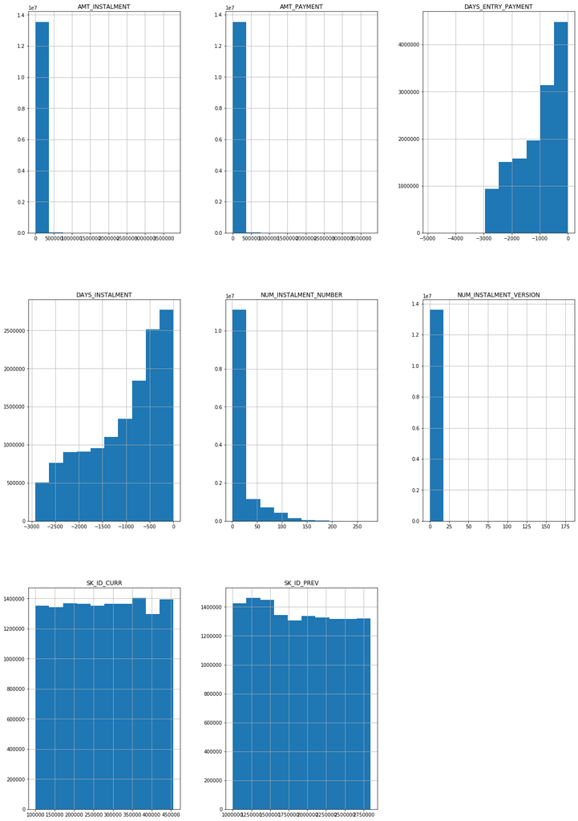

```python
df_installments = datasets['installments_payments']
basic_eda(df_installments, 'installments_payments')
```

### SK_ID_PREV and SK_ID_CURR

```python
print("* All records have distinct SK_ID_CURR? \t", len(df_installments['SK_ID_CURR'].unique()) == df_installments.shape[0])
print("* Total number of unique SK_ID_CURR   : \t", len(df_installments['SK_ID_CURR'].unique()))
print("* All records have distinct SK_ID_PREV? \t", len(df_installments['SK_ID_PREV'].unique()) == df_installments.shape[0])
print("* Total number of unique SK_ID_PREV   : \t", len(df_installments['SK_ID_PREV'].unique()))
```

```
* All records have distinct SK_ID_CURR? 	 False
* Total number of unique SK_ID_CURR   : 	 339587
* All records have distinct SK_ID_PREV? 	 False
* Total number of unique SK_ID_PREV   : 	 997752
```

# Feature engineering

## New features planned

- Application_train (and test)
  - Debt to income ratio
  - Number of flag documents provided
  - Income per family member
  - Excess of the loan amount over the price of the underlying goods
- POS_CASH_balance
  - How many installments are not yet paid (CNT_INSTALMENT_FUTURE)
  - Total number of previous loans
  - Total number of previous loans per status
  - Min and max terms of previous loans
- credit_card_balance
  - Average Monthly Balance per previous loans
  - Average Credit Card Limit per previous loans
  - Average Monthly Payments per previous loans
  - The percentage of over due payments per previous loans
- installments_payments
  - Payment_Days_over_installments
  - Payment_Amount_over_installments
- bureau & bureau_balance
  - Total overdue debt
  - Total debt
  - Number of active loans
  - Percent of debt attributed to credit cards
  - Percent of months with on-time payments

### Dictionary for additional datasets

```python
final_ds_names = ("bureau_final","credit_card_balance_final","installments_payments_final",
            "previous_application_final","POS_CASH_balance_final")

final_ds = dict()
```

## Dataset: application_train

### Loan amounts

```python
# Create a feature to see if the loan amount is larger than the value of the underlying goods
app_train['EXCESS_LOAN'] = app_train['AMT_CREDIT'] - app_train['AMT_GOODS_PRICE']
# app_train[app_train['EXCESS_LOAN'] < 0] = 0            # replaces all columns by 0
# app_train['EXCESS_LOAN'][app_train['EXCESS_LOAN'] < 0] = 0    # replaces all columns by 0

app_train['EXCESS_LOAN'].mask(app_train['EXCESS_LOAN']<0, 0, inplace=True)

# app_train.describe
# display(app_train.describe())
```

### Flag doucments

```python
# Create a feature to count how many of the flag documents were submitted
```

```python
flag_docs = ['SK_ID_CURR']
for cols in app_train.columns:
    if cols[0:8] == 'FLAG_DOC':
        flag_docs.append(cols)

flag_df = app_train[flag_docs]
flag_pivot = flag_df.melt(id_vars = 'SK_ID_CURR', var_name = 'Document', value_name = "FLAG_DOCS_SUBMITTED")
flag_counts = flag_pivot.groupby('SK_ID_CURR').sum()
flag_counts.head()
```

| SK_ID_CURR | FLAG_DOCS_SUBMITTED |
| --- | --- |
| 100002 | 1 |
| 100003 | 1 |
| 100004 | 0 |
| 100006 | 1 |
| 100007 | 1 |

```python
app_train_final = pd.merge(app_train, flag_counts, 'left', 'SK_ID_CURR')
```

### Income features

```python
# Create a feature to measure income per family member (maybe high income isn't as good with a large family)
```

```python
app_train_final['INCOME_PER_FAMILY_MEMBER'] = app_train_final['AMT_INCOME_TOTAL']/app_train_final['CNT_FAM_MEMBERS']
```

### Monthly debt/income

```python
# Create a feature to measure monthly debt/income
```

```python
app_train_final['DEBT_TO_INCOME'] = app_train_final['AMT_ANNUITY'] / (app_train_final['AMT_INCOME_TOTAL'] / 12)
```

### ADDITIONAL FEATURES ADDED ON PHASE 3

### AMT_CREDIT/AMT_ANNUITY

```python
app_train_final['AMT_CREDIT/AMT_ANNUITY'] = app_train_final['AMT_CREDIT'] / app_train_final['AMT_ANNUITY']
```

### AMT_CREDIT - AMT_GOODS_PRICE

```python
app_train_final['AMT_CREDIT - AMT_GOODS_PRICE'] = app_train_final['AMT_CREDIT'] - app_train_final['AMT_GOODS_PRICE']
```

### app AMT_INCOME_TOTAL / 12 - AMT_ANNUITY

```python
app_train_final['app AMT_INCOME_TOTAL / 12 - AMT_ANNUITY'] = app_train_final['AMT_INCOME_TOTAL'] / 12. - app_train_final['AMT_ANNUITY']
```

### DAYS_EMPLOYED / DAYS_BIRTH

```python
# how much work experience compare to his age
app_train_final['DAYS_EMPLOYED / DAYS_BIRTH'] = app_train_final['DAYS_EMPLOYED']/app_train_final['DAYS_BIRTH']
```

### EXT_SOURCE_MEAN

```python
# the average of all 3 types of Normalized score from external data sources.
app_train_final['EXT_SOURCE_MEAN'] = (app_train_final['EXT_SOURCE_1'] + app_train_final['EXT_SOURCE_2'] + app_train_final['EXT_SOURCE_3'])/3
```

```python
### EXT_SOURCE_MORE
```

```python
# Since EXT_SOURCE has been on my top feature imortance, we want to try the combination of them as well shown below:

app_train_final['EXT_SOURCE_STD']=app_train_final[['EXT_SOURCE_1', 'EXT_SOURCE_2', 'EXT_SOURCE_3']].std(axis = 1)
app_train_final['app EXT_SOURCE prod'] = app_train_final['EXT_SOURCE_1'] * app_train_final['EXT_SOURCE_2'] * app_train_final['EXT_SOURCE_3']
app_train_final['app EXT_SOURCE_1 * EXT_SOURCE_2'] = app_train_final['EXT_SOURCE_1'] * app_train_final['EXT_SOURCE_2']
app_train_final['app EXT_SOURCE_1 * EXT_SOURCE_3'] = app_train_final['EXT_SOURCE_1'] * app_train_final['EXT_SOURCE_3']
app_train_final['app EXT_SOURCE_2 * EXT_SOURCE_3'] = app_train_final['EXT_SOURCE_2'] * app_train_final['EXT_SOURCE_3']
```

### Higher Education

```python
# how much people get higher education, if it is shown as one, otherwise show 0

from collections import Counter
Counter(app_train_final['NAME_EDUCATION_TYPE'])
```

```
Counter({'Secondary / secondary special': 218391,
         'Higher education': 74863,
         'Incomplete higher': 10277,
         'Lower secondary': 3816,
         'Academic degree': 164})
```

```python
app_train_final['NAME_EDUCATION_TYPE_higher_education'] = app_train_final['NAME_EDUCATION_TYPE'].map(lambda x: 1 if x=='Higher education' else 0)
```

```python
app_train_final['NAME_EDUCATION_TYPE_higher_education']
```

```
0         0
1         1
2         0
3         0
4         0
         ..
307506    0
307507    0
307508    1
307509    0
307510    1
Name: NAME_EDUCATION_TYPE_higher_education, Length: 307511, dtype: int64
```

```python
app_train_final.shape
```

```
(307511, 137)
```

```python
# app_train_final.columns.tolist()
```

```python
## Show final dataframe after adding additional features

app_train_final.head(15)
```

|  | SK_ID_CURR | TARGET | NAME_CONTRACT_TYPE | CODE_GENDER | FLAG_OWN_CAR | FLAG_OWN_REALTY | CNT_CHILDREN | AMT_INCOME_TOTAL | AMT_CREDIT | AMT_ANNUITY | ... | AMT_CREDIT - AMT_GOODS_PRICE | app AMT_INCOME_TOTAL / 12 - AMT_ANNUITY | DAYS_EMPLOYED / DAYS_BIRTH | EXT_SOURCE_MEAN | EXT_SOURCE_STD | app EXT_SOURCE prod | app EXT_SOURCE_1 * EXT_SOURCE_2 | app EXT_SOURCE_1 * EXT_SOURCE_3 | app EXT_SOURCE_2 * EXT_SOURCE_3 | NAME_EDUCATION_TYPE_higher_education |
| --- | --- | --- | --- | --- | --- | --- | --- | --- | --- | --- | --- | --- | --- | --- | --- | --- | --- | --- | --- | --- | --- |
| 0 | 100002 | 1 | Cash loans | M | N | Y | 0 | 202500.000 | 406597.5 | 24700.5 | ... | 55597.5 | -7825.50000 | -0.067329 | 0.161787 | 0.092026 | 0.003043 | 0.021834 | 0.011573 | 0.036649 | 0 |
| 1 | 100003 | 0 | Cash loans | F | N | N | 0 | 270000.000 | 1293502.5 | 35698.5 | ... | 164002.5 | -13198.50000 | -0.070862 | NaN | 0.219895 | NaN | 0.193685 | NaN | NaN | 1 |
| 2 | 100004 | 0 | Revolving loans | M | Y | Y | 0 | 67500.000 | 135000.0 | 6750.0 | ... | 0.0 | -1125.00000 | -0.011814 | NaN | 0.122792 | NaN | NaN | NaN | 0.405575 | 0 |
| 3 | 100006 | 0 | Cash loans | F | N | Y | 0 | 135000.000 | 312682.5 | 29686.5 | ... | 15682.5 | -18436.50000 | -0.159905 | NaN | NaN | NaN | NaN | NaN | NaN | 0 |
| 4 | 100007 | 0 | Cash loans | M | N | Y | 0 | 121500.000 | 513000.0 | 21865.5 | ... | 0.0 | -11740.50000 | -0.152418 | NaN | NaN | NaN | NaN | NaN | NaN | 0 |
| 5 | 100008 | 0 | Cash loans | M | N | Y | 0 | 99000.000 | 490495.5 | 27517.5 | ... | 35995.5 | -19267.50000 | -0.093737 | NaN | 0.188799 | NaN | NaN | NaN | 0.220054 | 0 |
| 6 | 100009 | 0 | Cash loans | F | Y | Y | 1 | 171000.000 | 1560726.0 | 41301.0 | ... | 165726.0 | -27051.00000 | -0.227174 | 0.663607 | 0.150717 | 0.276010 | 0.560927 | 0.381229 | 0.356251 | 1 |
| 7 | 100010 | 0 | Cash loans | M | Y | Y | 0 | 360000.000 | 1530000.0 | 42075.0 | ... | 0.0 | -12075.00000 | -0.023820 | NaN | 0.122771 | NaN | NaN | NaN | 0.386178 | 1 |
| 8 | 100011 | 0 | Cash loans | F | N | Y | 0 | 112500.000 | 1019610.0 | 33826.5 | ... | 106110.0 | -24451.50000 | NaN | 0.514935 | 0.280096 | 0.090840 | 0.120842 | 0.441513 | 0.154665 | 0 |
| 9 | 100012 | 0 | Revolving loans | M | N | Y | 0 | 135000.000 | 405000.0 | 20250.0 | ... | 0.0 | -9000.00000 | -0.139540 | NaN | NaN | NaN | NaN | NaN | NaN | 0 |
| 10 | 100014 | 0 | Cash loans | F | N | Y | 1 | 112500.000 | 652500.0 | 21177.0 | ... | 0.0 | -11802.00000 | -0.066588 | 0.445189 | 0.180342 | 0.075861 | 0.208440 | 0.116375 | 0.237242 | 1 |
| 11 | 100015 | 0 | Cash loans | F | N | Y | 0 | 38419.155 | 148365.0 | 10678.5 | ... | 13365.0 | -7476.90375 | NaN | 0.643375 | 0.083837 | 0.261725 | 0.400867 | 0.471420 | 0.362477 | 0 |
| 12 | 100016 | 0 | Cash loans | F | N | Y | 0 | 67500.000 | 80865.0 | 5881.5 | ... | 13365.0 | -256.50000 | -0.202173 | 0.452175 | 0.269418 | 0.058715 | 0.332374 | 0.082114 | 0.126314 | 0 |
| 13 | 100017 | 0 | Cash loans | M | Y | N | 1 | 225000.000 | 918468.0 | 28966.5 | ... | 220968.0 | -10216.50000 | -0.214965 | NaN | 0.143670 | NaN | NaN | NaN | 0.436567 | 0 |
| 14 | 100018 | 0 | Cash loans | F | N | Y | 0 | 189000.000 | 773680.5 | 32778.0 | ... | 94180.5 | -17028.00000 | -0.013920 | NaN | 0.056062 | NaN | 0.463959 | NaN | NaN | 0 |

15 rows × 137 columns

## Dataset: Application_Test

We will duplicate the new features created for the Train data for the test data as well

```python
# app_test = datasets['application_test']

app_test['EXCESS_LOAN'] = app_test['AMT_CREDIT'] - app_test['AMT_GOODS_PRICE']
app_test['EXCESS_LOAN'].mask(app_test['EXCESS_LOAN']<0, 0, inplace=True)
app_test.head()
```

|  | SK_ID_CURR | NAME_CONTRACT_TYPE | CODE_GENDER | FLAG_OWN_CAR | FLAG_OWN_REALTY | CNT_CHILDREN | AMT_INCOME_TOTAL | AMT_CREDIT | AMT_ANNUITY | AMT_GOODS_PRICE | ... | FLAG_DOCUMENT_19 | FLAG_DOCUMENT_20 | FLAG_DOCUMENT_21 | AMT_REQ_CREDIT_BUREAU_HOUR | AMT_REQ_CREDIT_BUREAU_DAY | AMT_REQ_CREDIT_BUREAU_WEEK | AMT_REQ_CREDIT_BUREAU_MON | AMT_REQ_CREDIT_BUREAU_QRT | AMT_REQ_CREDIT_BUREAU_YEAR | EXCESS_LOAN |
| --- | --- | --- | --- | --- | --- | --- | --- | --- | --- | --- | --- | --- | --- | --- | --- | --- | --- | --- | --- | --- | --- |
| 0 | 100001 | Cash loans | F | N | Y | 0 | 135000.0 | 568800.0 | 20560.5 | 450000.0 | ... | 0 | 0 | 0 | 0.0 | 0.0 | 0.0 | 0.0 | 0.0 | 0.0 | 118800.0 |
| 1 | 100005 | Cash loans | M | N | Y | 0 | 99000.0 | 222768.0 | 17370.0 | 180000.0 | ... | 0 | 0 | 0 | 0.0 | 0.0 | 0.0 | 0.0 | 0.0 | 3.0 | 42768.0 |
| 2 | 100013 | Cash loans | M | Y | Y | 0 | 202500.0 | 663264.0 | 69777.0 | 630000.0 | ... | 0 | 0 | 0 | 0.0 | 0.0 | 0.0 | 0.0 | 1.0 | 4.0 | 33264.0 |
| 3 | 100028 | Cash loans | F | N | Y | 2 | 315000.0 | 1575000.0 | 49018.5 | 1575000.0 | ... | 0 | 0 | 0 | 0.0 | 0.0 | 0.0 | 0.0 | 0.0 | 3.0 | 0.0 |
| 4 | 100038 | Cash loans | M | Y | N | 1 | 180000.0 | 625500.0 | 32067.0 | 625500.0 | ... | 0 | 0 | 0 | NaN | NaN | NaN | NaN | NaN | NaN | 0.0 |

5 rows × 122 columns

```python
flag_docs = ['SK_ID_CURR']
for cols in app_test.columns:
    if cols[0:8] == 'FLAG_DOC':
        flag_docs.append(cols)

flag_df = app_test[flag_docs]
flag_pivot = flag_df.melt(id_vars = 'SK_ID_CURR', var_name = 'Document', value_name = "FLAG_DOCS_SUBMITTED")
flag_counts = flag_pivot.groupby('SK_ID_CURR').sum()
flag_counts.head()
```

| SK_ID_CURR | FLAG_DOCS_SUBMITTED |
| --- | --- |
| 100001 | 1 |
| 100005 | 1 |
| 100013 | 1 |
| 100028 | 1 |
| 100038 | 1 |

```python
app_test_final = pd.merge(app_test, flag_counts, 'left', 'SK_ID_CURR')
```

```python
app_test_final['INCOME_PER_FAMILY_MEMBER'] = app_test_final['AMT_INCOME_TOTAL']/app_test_final['CNT_FAM_MEMBERS']
```

```python
app_test_final['DEBT_TO_INCOME'] = app_test_final['AMT_ANNUITY'] / (app_test_final['AMT_INCOME_TOTAL'] / 12)
```

### ADDITIONAL FEATURES ADDED ON PHASE 3

### AMT_CREDIT/AMT_ANNUITY

```python
app_test_final['AMT_CREDIT/AMT_ANNUITY'] = app_test_final['AMT_CREDIT'] / app_test_final['AMT_ANNUITY']
```

### AMT_CREDIT - AMT_GOODS_PRICE

```python
app_test_final['AMT_CREDIT - AMT_GOODS_PRICE'] = app_test_final['AMT_CREDIT'] - app_test_final['AMT_GOODS_PRICE']
```

### app AMT_INCOME_TOTAL / 12 - AMT_ANNUITY

```python
app_test_final['app AMT_INCOME_TOTAL / 12 - AMT_ANNUITY'] = app_test_final['AMT_INCOME_TOTAL'] / 12. - app_test_final['AMT_ANNUITY']
```

### DAYS_EMPLOYED / DAYS_BIRTH

```python
app_test_final['DAYS_EMPLOYED / DAYS_BIRTH'] = app_test_final['DAYS_EMPLOYED']/app_test_final['DAYS_BIRTH']
```

### EXT_SOURCE_MEAN

```python
app_test_final['EXT_SOURCE_MEAN'] = (app_test_final['EXT_SOURCE_1'] + app_test_final['EXT_SOURCE_2'] + app_test_final['EXT_SOURCE_3'])/3
```

### EXT_SOURCE_MORE

```python
# Since EXT_SOURCE has been on my top feature imortance, we want to try the combination of them as well shown below:

app_test_final['EXT_SOURCE_STD']=app_test_final[['EXT_SOURCE_1', 'EXT_SOURCE_2', 'EXT_SOURCE_3']].std(axis = 1)
app_test_final['app EXT_SOURCE prod'] = app_test_final['EXT_SOURCE_1'] * app_test_final['EXT_SOURCE_2'] * app_train_final['EXT_SOURCE_3']
app_test_final['app EXT_SOURCE_1 * EXT_SOURCE_2'] = app_test_final['EXT_SOURCE_1'] * app_test_final['EXT_SOURCE_2']
app_test_final['app EXT_SOURCE_1 * EXT_SOURCE_3'] = app_test_final['EXT_SOURCE_1'] * app_test_final['EXT_SOURCE_3']
app_test_final['app EXT_SOURCE_2 * EXT_SOURCE_3'] = app_test_final['EXT_SOURCE_2'] * app_test_final['EXT_SOURCE_3']
```

### higher education

```python
app_test_final['NAME_EDUCATION_TYPE_higher_education'] = app_test_final['NAME_EDUCATION_TYPE'].map(lambda x: 1 if x=='Higher education' else 0)
```

```python
app_test_final.shape
```

```
(48744, 136)
```

```python
# app_test_final.columns.tolist()
```

```python
## Show final dataframe after adding additional features

app_test_final.head(15)
```

|  | SK_ID_CURR | NAME_CONTRACT_TYPE | CODE_GENDER | FLAG_OWN_CAR | FLAG_OWN_REALTY | CNT_CHILDREN | AMT_INCOME_TOTAL | AMT_CREDIT | AMT_ANNUITY | AMT_GOODS_PRICE | ... | AMT_CREDIT - AMT_GOODS_PRICE | app AMT_INCOME_TOTAL / 12 - AMT_ANNUITY | DAYS_EMPLOYED / DAYS_BIRTH | EXT_SOURCE_MEAN | EXT_SOURCE_STD | app EXT_SOURCE prod | app EXT_SOURCE_1 * EXT_SOURCE_2 | app EXT_SOURCE_1 * EXT_SOURCE_3 | app EXT_SOURCE_2 * EXT_SOURCE_3 | NAME_EDUCATION_TYPE_higher_education |
| --- | --- | --- | --- | --- | --- | --- | --- | --- | --- | --- | --- | --- | --- | --- | --- | --- | --- | --- | --- | --- | --- |
| 0 | 100001 | Cash loans | F | N | Y | 0 | 135000.0 | 568800.0 | 20560.5 | 450000.0 | ... | 118800.0 | -9310.5 | 0.121044 | 0.567263 | 0.353601 | 0.082832 | 0.594305 | 0.120057 | 0.125965 | 1 |
| 1 | 100005 | Cash loans | M | N | Y | 0 | 99000.0 | 222768.0 | 17370.0 | 180000.0 | ... | 42768.0 | -9120.0 | 0.247398 | 0.429869 | 0.136694 | NaN | 0.164783 | 0.244619 | 0.126276 | 0 |
| 2 | 100013 | Cash loans | M | Y | Y | 0 | 202500.0 | 663264.0 | 69777.0 | 630000.0 | ... | 33264.0 | -52902.0 | 0.222477 | NaN | 0.062788 | NaN | NaN | NaN | 0.427564 | 1 |
| 3 | 100028 | Cash loans | F | N | Y | 2 | 315000.0 | 1575000.0 | 49018.5 | 1575000.0 | ... | 0.0 | -22768.5 | 0.133515 | 0.549372 | 0.055432 | NaN | 0.267955 | 0.322119 | 0.312281 | 0 |
| 4 | 100038 | Cash loans | M | Y | N | 1 | 180000.0 | 625500.0 | 32067.0 | 625500.0 | ... | 0.0 | -17067.0 | 0.168021 | NaN | 0.158068 | NaN | 0.086051 | NaN | NaN | 0 |
| 5 | 100042 | Cash loans | F | Y | Y | 0 | 270000.0 | 959688.0 | 34600.5 | 810000.0 | ... | 149688.0 | -12100.5 | 0.645506 | NaN | 0.166969 | NaN | NaN | NaN | 0.247017 | 0 |
| 6 | 100057 | Cash loans | M | Y | Y | 2 | 180000.0 | 499221.0 | 22117.5 | 373500.0 | ... | 125721.0 | -7117.5 | 0.154630 | 0.661065 | 0.095263 | 0.213805 | 0.434510 | 0.495512 | 0.371924 | 1 |
| 7 | 100065 | Cash loans | M | N | Y | 0 | 166500.0 | 180000.0 | 14220.0 | 180000.0 | ... | 0.0 | -345.0 | 0.145755 | 0.496896 | 0.161581 | 0.187359 | 0.346541 | 0.176577 | 0.191490 | 1 |
| 8 | 100066 | Cash loans | F | N | Y | 0 | 315000.0 | 364896.0 | 28957.5 | 315000.0 | ... | 49896.0 | -2707.5 | 0.079488 | 0.683331 | 0.146253 | 0.436842 | 0.581120 | 0.375562 | 0.422751 | 1 |
| 9 | 100067 | Cash loans | F | Y | Y | 1 | 162000.0 | 45000.0 | 5337.0 | 45000.0 | ... | 0.0 | 8163.0 | 0.252525 | 0.283159 | 0.140269 | NaN | 0.093668 | 0.040863 | 0.086331 | 1 |
| 10 | 100074 | Cash loans | F | N | Y | 0 | 67500.0 | 675000.0 | 25447.5 | 675000.0 | ... | 0.0 | -19822.5 | -15.430629 | NaN | 0.255562 | NaN | NaN | NaN | 0.197077 | 0 |
| 11 | 100090 | Cash loans | F | N | Y | 0 | 135000.0 | 261621.0 | 16848.0 | 216000.0 | ... | 45621.0 | -5598.0 | 0.229000 | 0.528981 | 0.198387 | 0.194519 | 0.297933 | 0.330314 | 0.171859 | 0 |
| 12 | 100091 | Cash loans | F | N | Y | 0 | 247500.0 | 296280.0 | 23539.5 | 225000.0 | ... | 71280.0 | -2914.5 | 0.075664 | 0.382873 | 0.107155 | 0.021857 | 0.123731 | 0.109335 | 0.195228 | 0 |
| 13 | 100092 | Cash loans | F | Y | Y | 0 | 90000.0 | 360000.0 | 18535.5 | 360000.0 | ... | 0.0 | -11035.5 | 0.181744 | 0.316969 | 0.053747 | 0.063464 | 0.082412 | 0.114569 | 0.101538 | 0 |
| 14 | 100106 | Revolving loans | M | N | Y | 0 | 180000.0 | 157500.0 | 7875.0 | 157500.0 | ... | 0.0 | 7125.0 | 0.151352 | NaN | 0.066438 | NaN | NaN | NaN | 0.281614 | 0 |

15 rows × 136 columns

## Dataset: POS_CASH_balance

### OHE on categorical features

```python
# OHE on latest value of NAME_CONTRACT_STATUS
```

```python
df_pos_cash_latest_status = df_pos_cash_latest[['SK_ID_PREV','SK_ID_CURR','NAME_CONTRACT_STATUS']]
df_pos_cash_latest_status.head()
```

|  | SK_ID_PREV | SK_ID_CURR | NAME_CONTRACT_STATUS |
| --- | --- | --- | --- |
| 45995 | 1000001 | 158271 | Completed |
| 2792302 | 1000002 | 101962 | Completed |
| 7085917 | 1000003 | 252457 | Active |
| 4078063 | 1000004 | 260094 | Completed |
| 7852623 | 1000005 | 176456 | Completed |

```python
df_dummies = pd.get_dummies(df_pos_cash_latest_status['NAME_CONTRACT_STATUS'])
df_dummies.head()
```

|  | Active | Amortized debt | Approved | Canceled | Completed | Demand | Returned to the store | Signed |
| --- | --- | --- | --- | --- | --- | --- | --- | --- |
| 45995 | 0 | 0 | 0 | 0 | 1 | 0 | 0 | 0 |
| 2792302 | 0 | 0 | 0 | 0 | 1 | 0 | 0 | 0 |
| 7085917 | 1 | 0 | 0 | 0 | 0 | 0 | 0 | 0 |
| 4078063 | 0 | 0 | 0 | 0 | 1 | 0 | 0 | 0 |
| 7852623 | 0 | 0 | 0 | 0 | 1 | 0 | 0 | 0 |

```python
df_pos_cash_latest_status = pd.concat([df_pos_cash_latest_status,df_dummies] , axis=1, sort=False)
df_pos_cash_latest_status.head()
```

|  | SK_ID_PREV | SK_ID_CURR | NAME_CONTRACT_STATUS | Active | Amortized debt | Approved | Canceled | Completed | Demand | Returned to the store | Signed |
| --- | --- | --- | --- | --- | --- | --- | --- | --- | --- | --- | --- |
| 45995 | 1000001 | 158271 | Completed | 0 | 0 | 0 | 0 | 1 | 0 | 0 | 0 |
| 2792302 | 1000002 | 101962 | Completed | 0 | 0 | 0 | 0 | 1 | 0 | 0 | 0 |
| 7085917 | 1000003 | 252457 | Active | 1 | 0 | 0 | 0 | 0 | 0 | 0 | 0 |
| 4078063 | 1000004 | 260094 | Completed | 0 | 0 | 0 | 0 | 1 | 0 | 0 | 0 |
| 7852623 | 1000005 | 176456 | Completed | 0 | 0 | 0 | 0 | 1 | 0 | 0 | 0 |

### Group by 'SK_ID_CURR' and 'SK_ID_PREV'

```python
d = {
    'SK_ID_PREV':['size'],
    'CNT_INSTALMENT_FUTURE':['min'],
    'CNT_INSTALMENT':['max']

}
df_agg = df_pos_cash.groupby(['SK_ID_CURR', 'SK_ID_PREV']).agg(d)
# display(df_agg.head())

df_agg.columns = df_agg.columns.droplevel()
# display(df_agg.head())
df_agg.reset_index(inplace=True)
# display(df_agg.head())
df_agg.columns=['SK_ID_CURR','SK_ID_PREV','Count','Remaining_repays','Initial_term']
display(df_agg.head())
```

|  | SK_ID_CURR | SK_ID_PREV | Count | Remaining_repays | Initial_term |
| --- | --- | --- | --- | --- | --- |
| 0 | 100001 | 1369693 | 5 | 0.0 | 4.0 |
| 1 | 100001 | 1851984 | 4 | 0.0 | 4.0 |
| 2 | 100002 | 1038818 | 19 | 6.0 | 24.0 |
| 3 | 100003 | 1810518 | 8 | 0.0 | 12.0 |
| 4 | 100003 | 2396755 | 12 | 1.0 | 12.0 |

### Add current statuses

```python
df_final = pd.merge(df_agg,df_pos_cash_latest_status,how='left')
```

```python
df_final.info()
```

```
<class 'pandas.core.frame.DataFrame'>
Int64Index: 936325 entries, 0 to 936324
Data columns (total 14 columns):
 #   Column                 Non-Null Count   Dtype
---  ------                 --------------   -----
 0   SK_ID_CURR             936325 non-null  int64
 1   SK_ID_PREV             936325 non-null  int64
 2   Count                  936325 non-null  int64
 3   Remaining_repays       935435 non-null  float64
 4   Initial_term           935435 non-null  float64
 5   NAME_CONTRACT_STATUS   936325 non-null  object
 6   Active                 936325 non-null  uint8
 7   Amortized debt         936325 non-null  uint8
 8   Approved               936325 non-null  uint8
 9   Canceled               936325 non-null  uint8
 10  Completed              936325 non-null  uint8
 11  Demand                 936325 non-null  uint8
 12  Returned to the store  936325 non-null  uint8
 13  Signed                 936325 non-null  uint8
dtypes: float64(2), int64(3), object(1), uint8(8)
memory usage: 57.1+ MB
```

```python
df_final.head()
```

|  | SK_ID_CURR | SK_ID_PREV | Count | Remaining_repays | Initial_term | NAME_CONTRACT_STATUS | Active | Amortized debt | Approved | Canceled | Completed | Demand | Returned to the store | Signed |
| --- | --- | --- | --- | --- | --- | --- | --- | --- | --- | --- | --- | --- | --- | --- |
| 0 | 100001 | 1369693 | 5 | 0.0 | 4.0 | Completed | 0 | 0 | 0 | 0 | 1 | 0 | 0 | 0 |
| 1 | 100001 | 1851984 | 4 | 0.0 | 4.0 | Completed | 0 | 0 | 0 | 0 | 1 | 0 | 0 | 0 |
| 2 | 100002 | 1038818 | 19 | 6.0 | 24.0 | Active | 1 | 0 | 0 | 0 | 0 | 0 | 0 | 0 |
| 3 | 100003 | 1810518 | 8 | 0.0 | 12.0 | Completed | 0 | 0 | 0 | 0 | 1 | 0 | 0 | 0 |
| 4 | 100003 | 2396755 | 12 | 1.0 | 12.0 | Active | 1 | 0 | 0 | 0 | 0 | 0 | 0 | 0 |

### Group by SK_ID_CURR

```python
d2 = {
    'SK_ID_PREV':['size'],
    'Remaining_repays':['sum'],
    'Initial_term':  ['min','max'],
    'Active':        ['sum'],
    'Amortized debt':['sum'],
    'Approved':      ['sum'],
    'Canceled':      ['sum'],
    'Completed':     ['sum'],
    'Demand':        ['sum'],
    'Returned to the store':['sum'],
    'Signed':        ['sum']
}
df_out = df_final.groupby('SK_ID_CURR').agg(d2)

# display(df_out.head())

df_out.columns = df_out.columns.droplevel()

df_out.reset_index(inplace=True)

df_out.columns=['SK_ID_CURR','Count','Total_Remaining_repays','Min_Initial_term','Max_Initial_term','Active','Amortized debt','Approved','Canceled','Completed','Demand','Returned to the store','Signed']
display(df_out.head())
```

|  | SK_ID_CURR | Count | Total_Remaining_repays | Min_Initial_term | Max_Initial_term | Active | Amortized debt | Approved | Canceled | Completed | Demand | Returned to the store | Signed |
| --- | --- | --- | --- | --- | --- | --- | --- | --- | --- | --- | --- | --- | --- |
| 0 | 100001 | 2 | 0.0 | 4.0 | 4.0 | 0 | 0 | 0 | 0 | 2 | 0 | 0 | 0 |
| 1 | 100002 | 1 | 6.0 | 24.0 | 24.0 | 1 | 0 | 0 | 0 | 0 | 0 | 0 | 0 |
| 2 | 100003 | 3 | 1.0 | 6.0 | 12.0 | 1 | 0 | 0 | 0 | 2 | 0 | 0 | 0 |
| 3 | 100004 | 1 | 0.0 | 4.0 | 4.0 | 0 | 0 | 0 | 0 | 1 | 0 | 0 | 0 |
| 4 | 100005 | 1 | 0.0 | 12.0 | 12.0 | 0 | 0 | 0 | 0 | 1 | 0 | 0 | 0 |

```python
final_ds['POS_CASH_balance_final'] = df_out
```

## Dataset: previous_application

```python
# Features selected by looking at the data
selected_features = ['SK_ID_PREV','SK_ID_CURR','NAME_CONTRACT_TYPE','AMT_ANNUITY','AMT_APPLICATION','AMT_CREDIT',
                     'AMT_GOODS_PRICE','WEEKDAY_APPR_PROCESS_START','HOUR_APPR_PROCESS_START',
                     'NAME_CONTRACT_STATUS','DAYS_DECISION','NAME_PORTFOLIO']

out_df = df_prev_app[selected_features]

out_df.loc[out_df['AMT_APPLICATION'] == 0, 'AMT_CREDIT'] = 0
out_df['CREDIT_TO_APP_RATIO'] = out_df['AMT_CREDIT'] / out_df['AMT_APPLICATION']

out_df['APPLIED_EXTRA'] = '0'
out_df.loc[out_df['AMT_APPLICATION'] > out_df['AMT_GOODS_PRICE'], 'APPLIED_EXTRA'] = '1'

out_df['WEEKDAY'] = out_df['WEEKDAY_APPR_PROCESS_START'].map({'MONDAY':'START','TUESDAY':'START','WEDNESDAY':'MID','THURSDAY':'MID','FRIDAY':'MID','SATURDAY':'END','SUNDAY':'END'})
out_df['TIME'] = out_df['HOUR_APPR_PROCESS_START'].map({0:'EARLY_MORN', 1:'EARLY_MORN', 2:'EARLY_MORN', 3:'EARLY_MORN', 4:'EARLY_MORN', 5:'EARLY_MORN', 6:'EARLY_MORN', 7:'EARLY_MORN', 8:'EARLY_MORN', 9:'MORN', 10:'MORN', 11:'MORN', 12:'MORN', 13:'AFTERNOON', 14:'AFTERNOON', 15:'AFTERNOON', 16:'AFTERNOON', 17:'AFTERNOON', 18:'EVENING', 19:'EVENING', 20:'EVENING', 21:'EVENING', 22:'EVENING', 23:'EVENING'})

out_df.drop(['AMT_GOODS_PRICE','WEEKDAY_APPR_PROCESS_START','HOUR_APPR_PROCESS_START'], axis=1, inplace=True)

print("Newly added freatures: ")
display(out_df.head())
```

```
Newly added freatures:
```

|  | SK_ID_PREV | SK_ID_CURR | NAME_CONTRACT_TYPE | AMT_ANNUITY | AMT_APPLICATION | AMT_CREDIT | NAME_CONTRACT_STATUS | DAYS_DECISION | NAME_PORTFOLIO | CREDIT_TO_APP_RATIO | APPLIED_EXTRA | WEEKDAY | TIME |
| --- | --- | --- | --- | --- | --- | --- | --- | --- | --- | --- | --- | --- | --- |
| 0 | 2030495 | 271877 | Consumer loans | 1730.430 | 17145.0 | 17145.0 | Approved | -73 | POS | 1.00000 | 0 | END | AFTERNOON |
| 1 | 2802425 | 108129 | Cash loans | 25188.615 | 607500.0 | 679671.0 | Approved | -164 | Cash | 1.11880 | 0 | MID | MORN |
| 2 | 2523466 | 122040 | Cash loans | 15060.735 | 112500.0 | 136444.5 | Approved | -301 | Cash | 1.21284 | 0 | START | MORN |
| 3 | 2819243 | 176158 | Cash loans | 47041.335 | 450000.0 | 470790.0 | Approved | -512 | Cash | 1.04620 | 0 | START | EARLY_MORN |
| 4 | 1784265 | 202054 | Cash loans | 31924.395 | 337500.0 | 404055.0 | Refused | -781 | Cash | 1.19720 | 0 | MID | MORN |

### OHE on categorical features

```python
%%time

cat_features = list(out_df.select_dtypes(include='object').columns)
df_prev_app_cats = out_df[list(out_df.select_dtypes(include='object').columns)]
df_prev_app_nums = out_df[list(out_df.select_dtypes(exclude='object').columns)]

imputed = SimpleImputer(fill_value='missing', strategy='constant').fit_transform(df_prev_app_cats)

ohe = OneHotEncoder(sparse=False, handle_unknown="ignore", dtype=np.int).fit(imputed)
cat = pd.DataFrame(ohe.transform(imputed), index=df_prev_app_cats.index, columns=list(ohe.get_feature_names(cat_features)))

# cat = cat.astype('object')

cat.columns= ['PREV_APP_TYPE_Cashloans', 'PREV_APP_TYPE_Consumerloans', 'PREV_APP_TYPE_Revolvingloans', 'PREV_APP_TYPE_XNA', 'PREV_APP_STATUS_Approved', 'PREV_APP_STATUS_Canceled', 'PREV_APP_STATUS_Refused', 'PREV_APP_STATUS_Unusedoffer', 'PREV_APP_PORTFOLIO_Cards', 'PREV_APP_PORTFOLIO_Cars', 'PREV_APP_PORTFOLIO_Cash', 'PREV_APP_PORTFOLIO_POS', 'PREV_APP_PORTFOLIO_XNA', 'APPLIED_EXTRA_0', 'APPLIED_EXTRA_1', 'WEEKDAY_END', 'WEEKDAY_MID', 'WEEKDAY_START', 'TIME_AFTERNOON', 'TIME_EARLY_MORN', 'TIME_EVENING', 'TIME_MORN']

df_prev_app_new= pd.concat([out_df,cat], axis=1)
df_prev_app_new.drop(['NAME_CONTRACT_TYPE', 'NAME_CONTRACT_STATUS', 'NAME_PORTFOLIO', 'APPLIED_EXTRA', 'WEEKDAY', 'TIME'], axis=1,inplace=True)
display(df_prev_app_new.head())
```

|  | SK_ID_PREV | SK_ID_CURR | AMT_ANNUITY | AMT_APPLICATION | AMT_CREDIT | DAYS_DECISION | CREDIT_TO_APP_RATIO | PREV_APP_TYPE_Cashloans | PREV_APP_TYPE_Consumerloans | PREV_APP_TYPE_Revolvingloans | ... | PREV_APP_PORTFOLIO_XNA | APPLIED_EXTRA_0 | APPLIED_EXTRA_1 | WEEKDAY_END | WEEKDAY_MID | WEEKDAY_START | TIME_AFTERNOON | TIME_EARLY_MORN | TIME_EVENING | TIME_MORN |
| --- | --- | --- | --- | --- | --- | --- | --- | --- | --- | --- | --- | --- | --- | --- | --- | --- | --- | --- | --- | --- | --- |
| 0 | 2030495 | 271877 | 1730.430 | 17145.0 | 17145.0 | -73 | 1.00000 | 0 | 1 | 0 | ... | 0 | 1 | 0 | 1 | 0 | 0 | 1 | 0 | 0 | 0 |
| 1 | 2802425 | 108129 | 25188.615 | 607500.0 | 679671.0 | -164 | 1.11880 | 1 | 0 | 0 | ... | 0 | 1 | 0 | 0 | 1 | 0 | 0 | 0 | 0 | 1 |
| 2 | 2523466 | 122040 | 15060.735 | 112500.0 | 136444.5 | -301 | 1.21284 | 1 | 0 | 0 | ... | 0 | 1 | 0 | 0 | 0 | 1 | 0 | 0 | 0 | 1 |
| 3 | 2819243 | 176158 | 47041.335 | 450000.0 | 470790.0 | -512 | 1.04620 | 1 | 0 | 0 | ... | 0 | 1 | 0 | 0 | 0 | 1 | 0 | 1 | 0 | 0 |
| 4 | 1784265 | 202054 | 31924.395 | 337500.0 | 404055.0 | -781 | 1.19720 | 1 | 0 | 0 | ... | 0 | 1 | 0 | 0 | 1 | 0 | 0 | 0 | 0 | 1 |

5 rows × 29 columns

```
CPU times: user 4.14 s, sys: 882 ms, total: 5.02 s
Wall time: 5.55 s
```

### Aggreagate each type of loans

```python
%%time
d = {
'SK_ID_PREV'                    : ['size'],
'AMT_ANNUITY'                   : ['mean'],
'AMT_APPLICATION'               : ['mean'],
'AMT_CREDIT'                    : ['mean'],
'DAYS_DECISION'                 : ['mean'],
'CREDIT_TO_APP_RATIO'           : ['mean'],
'PREV_APP_TYPE_Cashloans'       : ['sum'],
'PREV_APP_TYPE_Consumerloans'   : ['sum'],
'PREV_APP_TYPE_Revolvingloans'  : ['sum'],
'PREV_APP_TYPE_XNA'             : ['sum'],
'PREV_APP_STATUS_Approved'      : ['sum'],
'PREV_APP_STATUS_Canceled'      : ['sum'],
'PREV_APP_STATUS_Refused'       : ['sum'],
'PREV_APP_STATUS_Unusedoffer'   : ['sum'],
'PREV_APP_PORTFOLIO_Cards'      : ['sum'],
'PREV_APP_PORTFOLIO_Cars'       : ['sum'],
'PREV_APP_PORTFOLIO_Cash'       : ['sum'],
'PREV_APP_PORTFOLIO_POS'        : ['sum'],
'PREV_APP_PORTFOLIO_XNA'        : ['sum'],
'APPLIED_EXTRA_0'               : ['sum'],
'APPLIED_EXTRA_1'               : ['sum'],
'WEEKDAY_END'                   : ['sum'],
'WEEKDAY_MID'                   : ['sum'],
'WEEKDAY_START'                 : ['sum'],
'TIME_AFTERNOON'                : ['sum'],
'TIME_EARLY_MORN'               : ['sum'],
'TIME_EVENING'                  : ['sum'],
'TIME_MORN'                     : ['sum'],
}

df_out = df_prev_app_new.groupby(by='SK_ID_CURR').agg(d)

# print("1")
# display(df_out)
df_out.columns = df_out.columns.droplevel(1)

# print("2")
# display(df_out)
df_out.reset_index(inplace=True)

# print("3")
display(df_out)
```

|  | SK_ID_CURR | SK_ID_PREV | AMT_ANNUITY | AMT_APPLICATION | AMT_CREDIT | DAYS_DECISION | CREDIT_TO_APP_RATIO | PREV_APP_TYPE_Cashloans | PREV_APP_TYPE_Consumerloans | PREV_APP_TYPE_Revolvingloans | ... | PREV_APP_PORTFOLIO_XNA | APPLIED_EXTRA_0 | APPLIED_EXTRA_1 | WEEKDAY_END | WEEKDAY_MID | WEEKDAY_START | TIME_AFTERNOON | TIME_EARLY_MORN | TIME_EVENING | TIME_MORN |
| --- | --- | --- | --- | --- | --- | --- | --- | --- | --- | --- | --- | --- | --- | --- | --- | --- | --- | --- | --- | --- | --- |
| 0 | 100001 | 1 | 3951.000000 | 24835.500 | 23787.00 | -1740.000 | 0.957782 | 0 | 1 | 0 | ... | 0 | 1 | 0 | 0 | 1 | 0 | 1 | 0 | 0 | 0 |
| 1 | 100002 | 1 | 9251.775000 | 179055.000 | 179055.00 | -606.000 | 1.000000 | 0 | 1 | 0 | ... | 0 | 1 | 0 | 1 | 0 | 0 | 0 | 0 | 0 | 1 |
| 2 | 100003 | 3 | 56553.990000 | 435436.500 | 484191.00 | -1305.000 | 1.057664 | 1 | 2 | 0 | ... | 0 | 3 | 0 | 2 | 1 | 0 | 2 | 0 | 0 | 1 |
| 3 | 100004 | 1 | 5357.250000 | 24282.000 | 20106.00 | -815.000 | 0.828021 | 0 | 1 | 0 | ... | 0 | 1 | 0 | 0 | 1 | 0 | 0 | 1 | 0 | 0 |
| 4 | 100005 | 2 | 4813.200000 | 22308.750 | 20076.75 | -536.000 | 0.899950 | 1 | 1 | 0 | ... | 1 | 2 | 0 | 0 | 2 | 0 | 0 | 0 | 0 | 2 |
| ... | ... | ... | ... | ... | ... | ... | ... | ... | ... | ... | ... | ... | ... | ... | ... | ... | ... | ... | ... | ... | ... |
| 338852 | 456251 | 1 | 6605.910000 | 40455.000 | 40455.00 | -273.000 | 1.000000 | 0 | 1 | 0 | ... | 0 | 1 | 0 | 0 | 1 | 0 | 1 | 0 | 0 | 0 |
| 338853 | 456252 | 1 | 10074.465000 | 57595.500 | 56821.50 | -2497.000 | 0.986561 | 0 | 1 | 0 | ... | 0 | 1 | 0 | 0 | 1 | 0 | 0 | 0 | 0 | 1 |
| 338854 | 456253 | 2 | 4770.405000 | 24162.750 | 20625.75 | -2380.000 | 0.831397 | 0 | 2 | 0 | ... | 0 | 2 | 0 | 1 | 0 | 1 | 0 | 0 | 0 | 2 |
| 338855 | 456254 | 2 | 10681.132500 | 121317.750 | 134439.75 | -299.500 | 1.122050 | 0 | 2 | 0 | ... | 0 | 2 | 0 | 1 | 1 | 0 | 0 | 0 | 1 | 1 |
| 338856 | 456255 | 8 | 20775.391875 | 362770.875 | 424431.00 | -587.625 | 1.115884 | 4 | 3 | 1 | ... | 0 | 8 | 0 | 2 | 5 | 1 | 5 | 0 | 2 | 1 |

338857 rows × 29 columns

```
CPU times: user 2.29 s, sys: 233 ms, total: 2.52 s
Wall time: 2.52 s
```

```python
final_ds['previous_application_final'] = df_out
```

## Dataset: Bureau and Bureau_balance

### Feature Engineering

```python
# Avg_installment_days_difference and Avg_installment_amount_difference
# Let's start with the bureau balance dataset first

bb_df = datasets['bureau_balance']
```

### Late Payments

```python
## We are going to focus on the number of months that had a late payment

tot_month_counts = bb_df.groupby('SK_ID_BUREAU').count()['STATUS']
late_month_counts = bb_df[(bb_df['STATUS'] != '0') & (bb_df['STATUS'] != 'C') & (bb_df['STATUS'] != 'X')].groupby('SK_ID_BUREAU').count()['STATUS']
status_df = pd.merge(left = tot_month_counts, right = late_month_counts, how = 'left', on = "SK_ID_BUREAU", suffixes = ('_tot', '_late'))

status_df.fillna(0, inplace = True)
status_df.head()
```

| SK_ID_BUREAU | STATUS_tot | STATUS_late |
| --- | --- | --- |
| 5001709 | 97 | 0.0 |
| 5001710 | 83 | 0.0 |
| 5001711 | 4 | 0.0 |
| 5001712 | 19 | 0.0 |
| 5001713 | 22 | 0.0 |

```python
## Now let's work on the bureau dataset

bureau_df = datasets['bureau']
bureau_df.head()
```

|  | SK_ID_CURR | SK_ID_BUREAU | CREDIT_ACTIVE | CREDIT_CURRENCY | DAYS_CREDIT | CREDIT_DAY_OVERDUE | DAYS_CREDIT_ENDDATE | DAYS_ENDDATE_FACT | AMT_CREDIT_MAX_OVERDUE | CNT_CREDIT_PROLONG | AMT_CREDIT_SUM | AMT_CREDIT_SUM_DEBT | AMT_CREDIT_SUM_LIMIT | AMT_CREDIT_SUM_OVERDUE | CREDIT_TYPE | DAYS_CREDIT_UPDATE | AMT_ANNUITY |
| --- | --- | --- | --- | --- | --- | --- | --- | --- | --- | --- | --- | --- | --- | --- | --- | --- | --- |
| 0 | 215354 | 5714462 | Closed | currency 1 | -497 | 0 | -153.0 | -153.0 | NaN | 0 | 91323.0 | 0.0 | NaN | 0.0 | Consumer credit | -131 | NaN |
| 1 | 215354 | 5714463 | Active | currency 1 | -208 | 0 | 1075.0 | NaN | NaN | 0 | 225000.0 | 171342.0 | NaN | 0.0 | Credit card | -20 | NaN |
| 2 | 215354 | 5714464 | Active | currency 1 | -203 | 0 | 528.0 | NaN | NaN | 0 | 464323.5 | NaN | NaN | 0.0 | Consumer credit | -16 | NaN |
| 3 | 215354 | 5714465 | Active | currency 1 | -203 | 0 | NaN | NaN | NaN | 0 | 90000.0 | NaN | NaN | 0.0 | Credit card | -16 | NaN |
| 4 | 215354 | 5714466 | Active | currency 1 | -629 | 0 | 1197.0 | NaN | 77674.5 | 0 | 2700000.0 | NaN | NaN | 0.0 | Consumer credit | -21 | NaN |

### See if there are credits opened or closed in the last year

```python
#create a feature that checks whether or not the credit closed within the last year
bureau_df['CLOSED_IN_LAST_YEAR'] = bureau_df['DAYS_ENDDATE_FACT'].mask(bureau_df['DAYS_ENDDATE_FACT'] >= -365, 1)
bureau_df['CLOSED_IN_LAST_YEAR'].fillna(0, inplace = True)
bureau_df['CLOSED_IN_LAST_YEAR'].mask(bureau_df['CLOSED_IN_LAST_YEAR'] <0, 0, inplace = True)

#create a feature that checks whether or not the credit was opened within the last year
bureau_df['OPENED_IN_LAST_YEAR'] = bureau_df['DAYS_CREDIT'].mask(bureau_df['DAYS_CREDIT'] >= -365, 1)
bureau_df['OPENED_IN_LAST_YEAR'].fillna(0, inplace = True)
bureau_df['OPENED_IN_LAST_YEAR'].mask(bureau_df['OPENED_IN_LAST_YEAR'] <0, 0, inplace = True)
```

### Pick out just the credit card data

```python
## Pick out just the credit card data

cc_debt_df = bureau_df[bureau_df['CREDIT_TYPE'] == 'Credit card']
cc_debt_df.drop(cc_debt_df.columns.difference(['SK_ID_CURR','CREDIT_TYPE', 'AMT_CREDIT_SUM_DEBT']), 1, inplace=True)
cc_debt_df = cc_debt_df.groupby('SK_ID_CURR').sum()
cc_debt_df.rename({'SK_ID_CURR': 'SK_ID_CURR', 'AMT_CREDIT_SUM_DEBT': 'CREDIT_CARD_DEBT'}, axis = 1, inplace = True)
cc_debt_df.head()
```

| SK_ID_CURR | CREDIT_CARD_DEBT |
| --- | --- |
| 100002 | 0.0 |
| 100003 | 0.0 |
| 100005 | 0.0 |
| 100009 | 326628.0 |
| 100011 | 0.0 |

### Count how many active loans

```python
## Count how many active loans the applicant has when they are applying for the Home Credit loan

active_df = bureau_df[bureau_df['CREDIT_ACTIVE'] == 'Active']
active_df.drop(active_df.columns.difference(['SK_ID_CURR','CREDIT_ACTIVE']), 1, inplace=True)
active_df = active_df.groupby('SK_ID_CURR').count()
active_df.rename({'SK_ID_CURR': 'SK_ID_CURR', 'CREDIT_ACTIVE': 'TOTAL_ACTIVE_LOANS'}, axis = 1, inplace = True)
active_df.head()
```

| SK_ID_CURR | TOTAL_ACTIVE_LOANS |
| --- | --- |
| 100001 | 3 |
| 100002 | 2 |
| 100003 | 1 |
| 100005 | 2 |
| 100008 | 1 |

```python
bureau_df.drop(bureau_df.columns.difference(['SK_ID_CURR','AMT_CREDIT_SUM_OVERDUE', 'AMT_CREDIT_SUM_DEBT', 'SK_ID_BUREAU', 'CREDIT_DAY_OVERDUE', 'AMT_CREDIT_MAX_OVERDUE', 'CNT_CREDIT_PROLONG', 'CLOSED_IN_LAST_YEAR', 'OPENED_IN_LAST_YEAR']), 1, inplace=True)
```

```python
## combine the bureau dataset with the late payment info from bureau_balance dataset

combined_bureau_df = pd.merge(bureau_df, status_df, 'left','SK_ID_BUREAU')
```

```python
combined_bureau_df.drop('SK_ID_BUREAU', inplace = True, axis = 1)
```

```python
combined_bureau_df = combined_bureau_df.groupby('SK_ID_CURR').agg({'CREDIT_DAY_OVERDUE' : np.mean,
                                                                   'AMT_CREDIT_MAX_OVERDUE' : np.max,
                                                                   'CNT_CREDIT_PROLONG' : np.mean,
                                                                   'AMT_CREDIT_SUM_DEBT' : np.sum,
                                                                   'AMT_CREDIT_SUM_OVERDUE' : np.sum,
                                                                   'CLOSED_IN_LAST_YEAR' : np.sum,
                                                                   'OPENED_IN_LAST_YEAR' : np.sum,
                                                                   'STATUS_tot' : np.sum,
                                                                   'STATUS_late' : np.sum
                                                                  })
```

### Combine the datasets

```python
## combine the other features created from the bureau dataset

bureau_final = pd.merge(combined_bureau_df, active_df, 'left', 'SK_ID_CURR')
bureau_final = pd.merge(bureau_final, cc_debt_df, 'left', 'SK_ID_CURR')
```

```python
## transform/combine several features into new ones

bureau_final['Percent_Late'] = bureau_final['STATUS_late']/bureau_final['STATUS_tot']
bureau_final['PERCENT_CREDIT_CARD'] = bureau_final['CREDIT_CARD_DEBT']/bureau_final['AMT_CREDIT_SUM_DEBT']
```

```python
bureau_final.drop(['STATUS_tot', 'STATUS_late', 'CREDIT_CARD_DEBT'], axis = 1, inplace = True)
```

```python
## Make the columns headers more descriptive

bureau_final.rename({'AMT_CREDIT_SUM_DEBT': 'TOTAL_DEBT', 'AMT_CREDIT_SUM_OVERDUE': 'TOTAL_DEBT_OVERDUE', 'TOTAL_ACTIVE_LOANS': 'TOTAL_NUMBER_OF_ACTIVE_LOANS', 'Percent_Late': 'PERCENT_LATE'}, axis = 1, inplace = True)
bureau_final.head()
```

| SK_ID_CURR | CREDIT_DAY_OVERDUE | AMT_CREDIT_MAX_OVERDUE | CNT_CREDIT_PROLONG | TOTAL_DEBT | TOTAL_DEBT_OVERDUE | CLOSED_IN_LAST_YEAR | OPENED_IN_LAST_YEAR | TOTAL_NUMBER_OF_ACTIVE_LOANS | PERCENT_LATE | PERCENT_CREDIT_CARD |
| --- | --- | --- | --- | --- | --- | --- | --- | --- | --- | --- |
| 100001 | 0.0 | NaN | 0.0 | 596686.5 | 0.0 | 0.0 | 2 | 3.0 | 0.005814 | NaN |
| 100002 | 0.0 | 5043.645 | 0.0 | 245781.0 | 0.0 | 2.0 | 1 | 2.0 | 0.245455 | 0.0 |
| 100003 | 0.0 | 0.000 | 0.0 | 0.0 | 0.0 | 0.0 | 0 | 1.0 | NaN | NaN |
| 100004 | 0.0 | 0.000 | 0.0 | 0.0 | 0.0 | 0.0 | 0 | NaN | NaN | NaN |
| 100005 | 0.0 | 0.000 | 0.0 | 568408.5 | 0.0 | 1.0 | 2 | 2.0 | 0.000000 | 0.0 |

```python
## fill in Null values for two of the features

bureau_final['PERCENT_CREDIT_CARD'] = bureau_final['PERCENT_CREDIT_CARD'].fillna(0)
bureau_final['TOTAL_NUMBER_OF_ACTIVE_LOANS'] = bureau_final['TOTAL_NUMBER_OF_ACTIVE_LOANS'].fillna(0)
bureau_final.head()
```

| SK_ID_CURR | CREDIT_DAY_OVERDUE | AMT_CREDIT_MAX_OVERDUE | CNT_CREDIT_PROLONG | TOTAL_DEBT | TOTAL_DEBT_OVERDUE | CLOSED_IN_LAST_YEAR | OPENED_IN_LAST_YEAR | TOTAL_NUMBER_OF_ACTIVE_LOANS | PERCENT_LATE | PERCENT_CREDIT_CARD |
| --- | --- | --- | --- | --- | --- | --- | --- | --- | --- | --- |
| 100001 | 0.0 | NaN | 0.0 | 596686.5 | 0.0 | 0.0 | 2 | 3.0 | 0.005814 | 0.0 |
| 100002 | 0.0 | 5043.645 | 0.0 | 245781.0 | 0.0 | 2.0 | 1 | 2.0 | 0.245455 | 0.0 |
| 100003 | 0.0 | 0.000 | 0.0 | 0.0 | 0.0 | 0.0 | 0 | 1.0 | NaN | 0.0 |
| 100004 | 0.0 | 0.000 | 0.0 | 0.0 | 0.0 | 0.0 | 0 | 0.0 | NaN | 0.0 |
| 100005 | 0.0 | 0.000 | 0.0 | 568408.5 | 0.0 | 1.0 | 2 | 2.0 | 0.000000 | 0.0 |

```python
final_ds['bureau_final'] = bureau_final
```

## Dataset: installments_payments

### Create new features

```python
# create new features Avg_installment_days_difference and Avg_installment_amount_difference
```

```python
df_installments['installment_days_difference']=df_installments['DAYS_ENTRY_PAYMENT']-df_installments['DAYS_INSTALMENT']
df_installments['installment_amount_difference']=df_installments['AMT_PAYMENT']-df_installments['AMT_INSTALMENT']

df_installments['payment_over_installment_ratio']=df_installments['AMT_PAYMENT']/df_installments['AMT_INSTALMENT'].mean()
df_installments.head()
```

|  | SK_ID_PREV | SK_ID_CURR | NUM_INSTALMENT_VERSION | NUM_INSTALMENT_NUMBER | DAYS_INSTALMENT | DAYS_ENTRY_PAYMENT | AMT_INSTALMENT | AMT_PAYMENT | installment_days_difference | installment_amount_difference | payment_over_installment_ratio |
| --- | --- | --- | --- | --- | --- | --- | --- | --- | --- | --- | --- |
| 0 | 1054186 | 161674 | 1.0 | 6 | -1180.0 | -1187.0 | 6948.360 | 6948.360 | -7.0 | 0.000 | 0.407507 |
| 1 | 1330831 | 151639 | 0.0 | 34 | -2156.0 | -2156.0 | 1716.525 | 1716.525 | 0.0 | 0.000 | 0.100671 |
| 2 | 2085231 | 193053 | 2.0 | 1 | -63.0 | -63.0 | 25425.000 | 25425.000 | 0.0 | 0.000 | 1.491123 |
| 3 | 2452527 | 199697 | 1.0 | 3 | -2418.0 | -2426.0 | 24350.130 | 24350.130 | -8.0 | 0.000 | 1.428084 |
| 4 | 2714724 | 167756 | 1.0 | 2 | -1383.0 | -1366.0 | 2165.040 | 2160.585 | 17.0 | -4.455 | 0.126714 |

### ADDTIONAL FEATURES ADDED IN PHASE 3

### INS_DAYS_ENTRY_PAYMENT_MAX

```python
d = {
    'installment_days_difference':['mean'],
    'installment_amount_difference':['mean'],
#     ADDTIONAL FEATURES ADDED IN PHASE 3
    'DAYS_ENTRY_PAYMENT':['max'],
    'payment_over_installment_ratio': ['mean'],
    'AMT_PAYMENT': ['sum'],


}
df_ins_agg = df_installments.groupby(['SK_ID_CURR', 'SK_ID_PREV']).agg(d)
# display(df_ins_agg.head())

df_ins_agg.columns = df_ins_agg.columns.droplevel()
# display(df_ins_agg.head())
df_ins_agg.reset_index(inplace=True)
# display(df_ins_agg.head())
df_ins_agg.columns=['SK_ID_CURR','SK_ID_PREV','Avg_installment_days_difference', 'Avg_installment_amount_difference', 'INS_DAYS_ENTRY_PAYMENT_MAX', 'payment_over_installment_ratio', 'INS_AMT_PAYMENT_SUM']
display(df_ins_agg.head())
```

|  | SK_ID_CURR | SK_ID_PREV | Avg_installment_days_difference | Avg_installment_amount_difference | INS_DAYS_ENTRY_PAYMENT_MAX | payment_over_installment_ratio | INS_AMT_PAYMENT_SUM |
| --- | --- | --- | --- | --- | --- | --- | --- |
| 0 | 100001 | 1369693 | -15.500000 | 0.0 | -1628.0 | 0.428876 | 29250.900 |
| 1 | 100001 | 1851984 | 3.666667 | 0.0 | -2856.0 | 0.233517 | 11945.025 |
| 2 | 100002 | 1038818 | -20.421053 | 0.0 | -49.0 | 0.677926 | 219625.695 |
| 3 | 100003 | 1810518 | -4.428571 | 0.0 | -544.0 | 9.643202 | 1150977.330 |
| 4 | 100003 | 2396755 | -6.750000 | 0.0 | -1985.0 | 0.394766 | 80773.380 |

### Group by SK_ID_CURR

```python
d2 = {
    'Avg_installment_days_difference':['mean'],
    'Avg_installment_amount_difference':['mean'],
    'INS_DAYS_ENTRY_PAYMENT_MAX':['max'],
    'payment_over_installment_ratio': ['mean'],
    'INS_AMT_PAYMENT_SUM': ['sum']
}
df_ins_out = df_ins_agg.groupby('SK_ID_CURR').agg(d2)

# display(df_ins_out.head())

df_ins_out.columns = df_ins_out.columns.droplevel()

df_ins_out.reset_index(inplace=True)

df_ins_out.columns=['SK_ID_CURR','Avg_installment_days_difference', 'Avg_installment_amount_difference', 'INS_DAYS_ENTRY_PAYMENT_MAX', 'payment_over_installment_ratio', 'INS_AMT_PAYMENT_SUM']
display(df_ins_out.head())
```

|  | SK_ID_CURR | Avg_installment_days_difference | Avg_installment_amount_difference | INS_DAYS_ENTRY_PAYMENT_MAX | payment_over_installment_ratio | INS_AMT_PAYMENT_SUM |
| --- | --- | --- | --- | --- | --- | --- |
| 0 | 100001 | -5.916667 | 0.0 | -1628.0 | 0.331196 | 41195.925 |
| 1 | 100002 | -20.421053 | 0.0 | -49.0 | 0.677926 | 219625.695 |
| 2 | 100003 | -7.448413 | 0.0 | -544.0 | 4.607290 | 1618864.650 |
| 3 | 100004 | -7.666667 | 0.0 | -727.0 | 0.416175 | 21288.465 |
| 4 | 100005 | -23.555556 | 0.0 | -470.0 | 0.365975 | 56161.845 |

```python
final_ds['installments_payments_final'] = df_ins_out
```

## Dataset: credit_card_balance

### Percentage of Late Pyaments

```python
df_credit.columns
```

```
Index(['SK_ID_PREV', 'SK_ID_CURR', 'MONTHS_BALANCE', 'AMT_BALANCE',
       'AMT_CREDIT_LIMIT_ACTUAL', 'AMT_DRAWINGS_ATM_CURRENT',
       'AMT_DRAWINGS_CURRENT', 'AMT_DRAWINGS_OTHER_CURRENT',
       'AMT_DRAWINGS_POS_CURRENT', 'AMT_INST_MIN_REGULARITY',
       'AMT_PAYMENT_CURRENT', 'AMT_PAYMENT_TOTAL_CURRENT',
       'AMT_RECEIVABLE_PRINCIPAL', 'AMT_RECIVABLE', 'AMT_TOTAL_RECEIVABLE',
       'CNT_DRAWINGS_ATM_CURRENT', 'CNT_DRAWINGS_CURRENT',
       'CNT_DRAWINGS_OTHER_CURRENT', 'CNT_DRAWINGS_POS_CURRENT',
       'CNT_INSTALMENT_MATURE_CUM', 'NAME_CONTRACT_STATUS', 'SK_DPD',
       'SK_DPD_DEF'],
      dtype='object')
```

```python
tot_month_counts = df_credit.groupby('SK_ID_PREV').count()['MONTHS_BALANCE']
late_month_counts = df_credit[(df_credit['SK_DPD'] != 0)].groupby('SK_ID_PREV').count()['SK_DPD']
df_credit_late = pd.merge(left = tot_month_counts, right = late_month_counts, how = 'left', on = "SK_ID_PREV")

df_credit_late.fillna(0, inplace = True)
df_credit_late.head()
```

| SK_ID_PREV | MONTHS_BALANCE | SK_DPD |
| --- | --- | --- |
| 1000018 | 5 | 0.0 |
| 1000030 | 8 | 0.0 |
| 1000031 | 16 | 0.0 |
| 1000035 | 5 | 0.0 |
| 1000077 | 11 | 0.0 |

```python
df_credit_late['Payment_Pass_Due_Perc'] = df_credit_late['SK_DPD']/df_credit_late['MONTHS_BALANCE']
df_credit_late.head()
```

| SK_ID_PREV | MONTHS_BALANCE | SK_DPD | Payment_Pass_Due_Perc |
| --- | --- | --- | --- |
| 1000018 | 5 | 0.0 | 0.0 |
| 1000030 | 8 | 0.0 | 0.0 |
| 1000031 | 16 | 0.0 | 0.0 |
| 1000035 | 5 | 0.0 | 0.0 |
| 1000077 | 11 | 0.0 | 0.0 |

```python
d = {
    'AMT_BALANCE':['mean'],
    'AMT_CREDIT_LIMIT_ACTUAL':['mean'],
    'AMT_PAYMENT_TOTAL_CURRENT':['mean'],
    'SK_ID_CURR': ['count'],


}
df_credit_agg = df_credit.groupby(['SK_ID_CURR','SK_ID_PREV']).agg(d)


df_credit_agg.columns = df_credit_agg.columns.droplevel()

df_credit_agg.reset_index(inplace=True)

df_credit_agg.columns=['SK_ID_CURR', 'SK_ID_PREV','CC_Average_Monthly_Balance','CC_Average_Credit_Card_Limit', 'CC_Average_Monthly_Payments', 'CC_Credit_Cards_Count']
display(df_credit_agg.head())
```

|  | SK_ID_CURR | SK_ID_PREV | CC_Average_Monthly_Balance | CC_Average_Credit_Card_Limit | CC_Average_Monthly_Payments | CC_Credit_Cards_Count |
| --- | --- | --- | --- | --- | --- | --- |
| 0 | 100006 | 1489396 | 0.000000 | 270000.000000 | 0.000000 | 6 |
| 1 | 100011 | 1843384 | 54482.111149 | 164189.189189 | 4520.067568 | 74 |
| 2 | 100013 | 2038692 | 18159.919219 | 131718.750000 | 6817.172344 | 96 |
| 3 | 100021 | 2594025 | 0.000000 | 675000.000000 | 0.000000 | 17 |
| 4 | 100023 | 1499902 | 0.000000 | 135000.000000 | 0.000000 | 8 |

```python
combined_credit_df = pd.merge(df_credit_agg, df_credit_late, 'left','SK_ID_PREV')
#combined_credit_df.head()
dropped_credit_df=combined_credit_df.drop(columns=['MONTHS_BALANCE', 'SK_DPD'])
dropped_credit_df.head()
```

|  | SK_ID_CURR | SK_ID_PREV | CC_Average_Monthly_Balance | CC_Average_Credit_Card_Limit | CC_Average_Monthly_Payments | CC_Credit_Cards_Count | Payment_Pass_Due_Perc |
| --- | --- | --- | --- | --- | --- | --- | --- |
| 0 | 100006 | 1489396 | 0.000000 | 270000.000000 | 0.000000 | 6 | 0.000000 |
| 1 | 100011 | 1843384 | 54482.111149 | 164189.189189 | 4520.067568 | 74 | 0.000000 |
| 2 | 100013 | 2038692 | 18159.919219 | 131718.750000 | 6817.172344 | 96 | 0.010417 |
| 3 | 100021 | 2594025 | 0.000000 | 675000.000000 | 0.000000 | 17 | 0.000000 |
| 4 | 100023 | 1499902 | 0.000000 | 135000.000000 | 0.000000 | 8 | 0.000000 |

### Group by SK_ID_CURR

```python
d2 = {
    'CC_Average_Monthly_Balance':['sum'],
    'CC_Average_Credit_Card_Limit':['mean'],
    'CC_Average_Monthly_Payments':['sum'],
    'Payment_Pass_Due_Perc': ['mean'],
    'CC_Credit_Cards_Count': ['sum'],

}
df_credit_out = dropped_credit_df.groupby('SK_ID_CURR').agg(d2)

# display(df_out.head())

df_credit_out.columns = df_credit_out.columns.droplevel()

df_credit_out.reset_index(inplace=True)

df_credit_out.columns=['SK_ID_CURR','CC_Average_Monthly_Balance','CC_Average_Credit_Card_Limit', 'CC_Average_Monthly_Payments', 'CC_Average_percentage_pass_due', 'CC_Credit_Cards_Count']
display(df_credit_out.head(10))
```

|  | SK_ID_CURR | CC_Average_Monthly_Balance | CC_Average_Credit_Card_Limit | CC_Average_Monthly_Payments | CC_Average_percentage_pass_due | CC_Credit_Cards_Count |
| --- | --- | --- | --- | --- | --- | --- |
| 0 | 100006 | 0.000000 | 270000.000000 | 0.000000 | 0.000000 | 6 |
| 1 | 100011 | 54482.111149 | 164189.189189 | 4520.067568 | 0.000000 | 74 |
| 2 | 100013 | 18159.919219 | 131718.750000 | 6817.172344 | 0.010417 | 96 |
| 3 | 100021 | 0.000000 | 675000.000000 | 0.000000 | 0.000000 | 17 |
| 4 | 100023 | 0.000000 | 135000.000000 | 0.000000 | 0.000000 | 8 |
| 5 | 100028 | 8085.058163 | 225000.000000 | 5606.152347 | 0.000000 | 49 |
| 6 | 100036 | 0.000000 | 78750.000000 | 0.000000 | 0.000000 | 12 |
| 7 | 100042 | 33356.183036 | 78750.000000 | 7369.821429 | 0.023810 | 84 |
| 8 | 100043 | 208572.600000 | 287045.454545 | 13441.831364 | 0.000000 | 33 |
| 9 | 100047 | 0.000000 | 326250.000000 | 0.000000 | 0.000000 | 36 |

```python
final_ds['credit_card_balance_final'] = df_credit_out
```

## Final Engineered Datasets

```python
for i in final_ds.keys():
    print(i, " shape: ", final_ds[i].shape)
```

```
POS_CASH_balance_final  shape:  (337252, 13)
previous_application_final  shape:  (338857, 29)
bureau_final  shape:  (305811, 10)
installments_payments_final  shape:  (339587, 6)
credit_card_balance_final  shape:  (103558, 6)
```

# Merge Additional Datasets

```python
# Merge all 6 additional datasets to the training and testing sets

def merge_additional(df):
    df = pd.merge(df, final_ds['POS_CASH_balance_final'][['SK_ID_CURR','Count','Total_Remaining_repays','Max_Initial_term']],
                         'left', on='SK_ID_CURR')
    print("Merged POS_CASH_balance: ",  df.shape)

    df = pd.merge(df, final_ds['bureau_final'], 'left',  on='SK_ID_CURR')
    print("Merged bureau: ",  df.shape)

    df = pd.merge(df, final_ds['installments_payments_final'], 'left', on='SK_ID_CURR')
    print("Merged installments_payments: ",  df.shape)

    df = pd.merge(df, final_ds['previous_application_final'], 'left', on='SK_ID_CURR')
    print("Merged previous_application_final: ",  df.shape)

    df = pd.merge(df, final_ds['credit_card_balance_final'], 'left', on='SK_ID_CURR')
    print("Merged credit_card_balance_final: ",  df.shape)

    return df
```

```python
df_train = merge_additional(app_train_final)
df_test = merge_additional(app_test_final)
```

```
Merged POS_CASH_balance:  (307511, 140)
Merged bureau:  (307511, 150)
Merged installments_payments:  (307511, 155)
Merged previous_application_final:  (307511, 183)
Merged credit_card_balance_final:  (307511, 188)
Merged POS_CASH_balance:  (48744, 139)
Merged bureau:  (48744, 149)
Merged installments_payments:  (48744, 154)
Merged previous_application_final:  (48744, 182)
Merged credit_card_balance_final:  (48744, 187)
```

```python
print("Train: ", df_train.shape)
print("Test: ",  df_test.shape)
```

```
Train:  (307511, 188)
Test:  (48744, 187)
```

# Feature Selection

```python
correlations = df_train.corr()['TARGET'].sort_values()
```

```python
num_of_features = 100
```

```python
categoricals = list(df_train.select_dtypes(include = 'object').columns)
```

```python
# +1 in tail() so that TARGET is not considered in num_of_features
selected_features = list(correlations.tail(num_of_features//2 + 1).index) + list(correlations.head(num_of_features//2).index)
selected_features.remove('TARGET')

selected_features = selected_features + categoricals

print("Selected features= ", selected_features)
```

[output not shown]

```python
print(len(selected_features))
```

```
116
```

# Baseline Model

## Create train test split

```python
# Split the provided training data into training and validation. Not creating test dataset as test dataset is separate

from sklearn.model_selection import train_test_split

use_application_data_ONLY = True #use joined data
if use_application_data_ONLY:
     #just selected a few features for a baseline experiment
    selected_features_baseline = ['AMT_INCOME_TOTAL',  'AMT_CREDIT','DAYS_EMPLOYED','DAYS_BIRTH','EXT_SOURCE_1',
         'EXT_SOURCE_2','EXT_SOURCE_3','CODE_GENDER', 'FLAG_OWN_REALTY','FLAG_OWN_CAR','NAME_CONTRACT_TYPE',
                    'NAME_EDUCATION_TYPE','OCCUPATION_TYPE','NAME_INCOME_TYPE']
    X_train = datasets["application_train"][selected_features_baseline]
    y_train = datasets["application_train"]['TARGET']
    X_train, X_valid, y_train, y_valid = train_test_split(X_train, y_train, test_size=0.15, random_state=42)
    X_train, X_test, y_train, y_test = train_test_split(X_train, y_train, test_size=0.15, random_state=42)
    X_kaggle_test= datasets["application_test"][selected_features_baseline]
else:
    X_train = df_train[selected_features]
    y_train = df_test['TARGET']
    X_train, X_valid, y_train, y_valid = train_test_split(X_train, y_train, test_size=0.15,  random_state=42)
    X_train, X_test, y_train, y_test = train_test_split(X_train, y_train, test_size=0.15, random_state=42)
    X_kaggle_test= datasets["application_test"][selected_features]

print(f"X train           shape: {X_train.shape}")
print(f"Y train           shape: {y_train.shape}")
print()
print(f"X validation      shape: {X_valid.shape}")
print(f"Y validation      shape: {y_valid.shape}")
print()
print(f"X test            shape: {X_test.shape}")
print(f"Y test            shape: {y_test.shape}")
print()
print(f"X X_kaggle_test   shape: {X_kaggle_test.shape}")
print(f"Y X_kaggle_test is not available as the test dataset is from a Kaggel competition")
```

```
X train           shape: (222176, 14)
Y train           shape: (222176,)

X validation      shape: (46127, 14)
Y validation      shape: (46127,)

X test            shape: (39208, 14)
Y test            shape: (39208,)

X X_kaggle_test   shape: (48744, 14)
Y X_kaggle_test is not available as the test dataset is from a Kaggel competition
```

## Pipeline creation

```python
# Class from the starter notebook
# Create a class to select numerical or categorical columns
# since Scikit-Learn doesn't handle DataFrames yet
class DataFrameSelector(BaseEstimator, TransformerMixin):
    def __init__(self, attribute_names):
        self.attribute_names = attribute_names
    def fit(self, X, y=None):
        return self
    def transform(self, X):
        return X[self.attribute_names].values
```

```python
# seperate the featured into numerical and catagorical for pipelines

num_attribs = list(X_train.select_dtypes(exclude='object').columns)
cat_attribs = list(X_train.select_dtypes(include='object').columns)

num_pipeline = Pipeline([
        ('selector', DataFrameSelector(num_attribs)),
        ('imputer', SimpleImputer(strategy='mean')),
        ('std_scaler', StandardScaler()),
    ])

cat_pipeline = Pipeline([
        ('selector', DataFrameSelector(cat_attribs)),
        ('imputer', SimpleImputer(strategy='constant', fill_value='missing')),
        ('ohe', OneHotEncoder(sparse=False, handle_unknown="ignore"))
    ])

data_prep_pipeline = FeatureUnion(transformer_list=[
        ("num_pipeline", num_pipeline),
        ("cat_pipeline", cat_pipeline),
    ])
```

```python
print('Number of numberical features:', len(num_attribs))
print('Number of categorical features:', len(cat_attribs))
```

```
Number of numberical features: 7
Number of categorical features: 7
```

```python
def pct(x):
    return round(100*x,3)
```

## Create expLog

```python
try:
    expLog
except NameError:
    expLog = pd.DataFrame(columns=["exp_name",
                                   "Train Acc",
                                   "Valid Acc",
                                   "Test  Acc",
                                   "Train AUC",
                                   "Valid AUC",
                                   "Test  AUC",
                                   "Train Time"
                                  ])
```

## Run Baseline Model

```python
from time import time
start = time()

full_pipeline_with_predictor = Pipeline([
        ("preparation", data_prep_pipeline),
        ("linear", LogisticRegression())
    ])


model_0 = full_pipeline_with_predictor.fit(X_train, y_train)
train_time = np.round(time() - start, 4)
```

```python
from sklearn.metrics import accuracy_score

np.round(accuracy_score(y_train, model_0.predict(X_train)), 3)
```

```
0.92
```

```python
from sklearn.metrics import accuracy_score, roc_auc_score

exp_name = f"Baseline_{len(selected_features_baseline)}_features"
expLog.loc[len(expLog)] = [f"{exp_name}"] + list(np.round(
               [accuracy_score(y_train, model_0.predict(X_train)),
                accuracy_score(y_valid, model_0.predict(X_valid)),
                accuracy_score(y_test, model_0.predict(X_test)),
                roc_auc_score(y_train, model_0.predict_proba(X_train)[:, 1]),
                roc_auc_score(y_valid, model_0.predict_proba(X_valid)[:, 1]),
                roc_auc_score(y_test, model_0.predict_proba(X_test)[:, 1]),
                train_time
                ],4))

expLog
```

|  | exp_name | Train Acc | Valid Acc | Test Acc | Train AUC | Valid AUC | Test AUC | Train Time |
| --- | --- | --- | --- | --- | --- | --- | --- | --- |
| 0 | Baseline_14_features | 0.9198 | 0.9192 | 0.9159 | 0.7372 | 0.7381 | 0.7383 | 2.2682 |

# Model 1: Logistic Regression

```python
X_train = df_train[selected_features]
y_train = df_train['TARGET']
X_train, X_valid, y_train, y_valid = train_test_split(X_train, y_train, test_size=0.15,  random_state=42)
X_train, X_test, y_train, y_test = train_test_split(X_train, y_train, test_size=0.15, random_state=42)
X_kaggle_test= df_test[selected_features]

print(f"X train           shape: {X_train.shape}")
print(f"Y train           shape: {y_train.shape}")
print()
print(f"X validation      shape: {X_valid.shape}")
print(f"Y validation      shape: {y_valid.shape}")
print()
print(f"X test            shape: {X_test.shape}")
print(f"Y test            shape: {y_test.shape}")
print()
print(f"X X_kaggle_test   shape: {X_kaggle_test.shape}")
```

```
X train           shape: (222176, 116)
Y train           shape: (222176,)

X validation      shape: (46127, 116)
Y validation      shape: (46127,)

X test            shape: (39208, 116)
Y test            shape: (39208,)

X X_kaggle_test   shape: (48744, 116)
```

## Pipeline creation

```python
num_attribs = list(X_train.select_dtypes(exclude='object').columns)
print("Numerical Features are:")
print(num_attribs)
print("------------------------")
print('Number of numberical features: ', len(num_attribs))
```

```
Numerical Features are:
['Total_Remaining_repays', 'PREV_APP_TYPE_XNA', 'Max_Initial_term', 'TOTAL_DEBT_OVERDUE', 'DEBT_TO_INCOME', 'PREV_APP_PORTFOLIO_Cash', 'TIME_MORN', 'FLAG_DOCS_SUBMITTED', 'WEEKDAY_START', 'PREV_APP_STATUS_Canceled', 'CNT_CHILDREN', 'WEEKDAY_MID', 'CLOSED_IN_LAST_YEAR', 'SK_ID_PREV', 'APPLIED_EXTRA_0…
------------------------
Number of numberical features:  100
```

```python
print("Categorical Features are:")
cat_attribs = list(X_train.select_dtypes(include='object').columns)
print(cat_attribs)
print("------------------------")
print('Number of Categorical features: ', len(cat_attribs))
```

```
Categorical Features are:
['NAME_CONTRACT_TYPE', 'CODE_GENDER', 'FLAG_OWN_CAR', 'FLAG_OWN_REALTY', 'NAME_TYPE_SUITE', 'NAME_INCOME_TYPE', 'NAME_EDUCATION_TYPE', 'NAME_FAMILY_STATUS', 'NAME_HOUSING_TYPE', 'OCCUPATION_TYPE', 'WEEKDAY_APPR_PROCESS_START', 'ORGANIZATION_TYPE', 'FONDKAPREMONT_MODE', 'HOUSETYPE_MODE', 'WALLSMATERI…
------------------------
Number of Categorical features:  16
```

```python
# Logistic regression with our selected features

num_pipeline = Pipeline([
        ('selector', DataFrameSelector(num_attribs)),
        ('imputer', SimpleImputer(strategy='mean')),
        ('std_scaler', StandardScaler()),
    ])

cat_pipeline = Pipeline([
        ('selector', DataFrameSelector(cat_attribs)),
        #('imputer', SimpleImputer(strategy='most_frequent')),
        ('imputer', SimpleImputer(strategy='constant', fill_value='missing')),
        ('ohe', OneHotEncoder(sparse=False, handle_unknown="ignore"))
    ])

data_prep_pipeline = FeatureUnion(transformer_list=[
        ("num_pipeline", num_pipeline),
        ("cat_pipeline", cat_pipeline),
    ])
```

## Model execution

```python
from time import time
start = time()

full_pipeline_with_predictor = Pipeline([
        ("preparation", data_prep_pipeline),
        ("linear", LogisticRegression())
    ])


model_1 = full_pipeline_with_predictor.fit(X_train, y_train)
train_time = np.round(time() - start, 4)
```

```python
from sklearn.metrics import accuracy_score, roc_auc_score

exp_name = f"LogisticRegression_{len(selected_features)}_features"
expLog.loc[len(expLog)] = [f"{exp_name}"] + list(np.round(
               [accuracy_score(y_train, model_1.predict(X_train)),
                accuracy_score(y_valid, model_1.predict(X_valid)),
                accuracy_score(y_test, model_1.predict(X_test)),
                roc_auc_score(y_train, model_1.predict_proba(X_train)[:, 1]),
                roc_auc_score(y_valid, model_1.predict_proba(X_valid)[:, 1]),
                roc_auc_score(y_test, model_1.predict_proba(X_test)[:, 1]),
                train_time
                ],4))

expLog
```

|  | exp_name | Train Acc | Valid Acc | Test Acc | Train AUC | Valid AUC | Test AUC | Train Time |
| --- | --- | --- | --- | --- | --- | --- | --- | --- |
| 0 | Baseline_14_features | 0.9198 | 0.9192 | 0.9159 | 0.7372 | 0.7381 | 0.7383 | 2.2682 |
| 1 | LogisticRegression_116_features | 0.9200 | 0.9200 | 0.9162 | 0.7646 | 0.7621 | 0.7634 | 9.5147 |